# PHYS 210 Day 18

### 2026 - 11 - 23

Agenda:

1. Announcements: **Test 5 (Mon Nov 30 – Fri Dec 4): file I/O, reading and explaining code, Monte-Carlo 2; not cumulative; self-reserve is open** · Practice sets "Monte-Carlo 2" and "reading and explaining code" open on PrairieLearn after both sections today; Practice Test 5 opens Tue Nov 24 · **Homework 18 due Wed Nov 25, 9:00 am** · no reading for Wednesday · Project B: studio today, draft checkpoint Mon Nov 30, defences Mon Dec 7
2. Reading 18 recap and polls: random walks and the Metropolis rule
3. A gas of atoms: the Metropolis loop as the Project B pattern
4. Simulated annealing: the Metropolis loop with a cooling schedule
5. Reading and explaining code (Topic 15)
6. Looking back: what you can do now, and what is left
7. Project B studio

## Reading recap, Q&A and polling questions

Random walks first, then the Metropolis rule; three polls, then the chain idea

## Reading recap: a random walk is a chain

- Every example in the reading has the same four parts: **start** somewhere · **propose** a random change · **accept** it or stay · **repeat** and record the state after every step
- Each new position is made from the current one only: a **Markov chain**. Monte-Carlo 1 (Day 09) drew every number fresh and independent; this is new
- One walker is unpredictable; 2000 walkers are not: the mean stays at 0, the spread grows like $\sqrt{N}$, the histogram is a Gaussian
- Read backwards: to get a distance $d$ away, a walk needs about $d^2$ steps. Counting steps "until something happens" is a `while` loop

### Reading recap: the Metropolis rule in two lines

```
dE = energy(x + dx) - energy(x)
p = np.exp(-dE / kT)
if np.random.rand() < p:
    x = x + dx
positions[i] = x            # recorded after every step, rejected or not
```

- A move **down** ($dE \le 0$): $p \ge 1$, and `rand()` is always below 1, so it is always accepted
- A move **up** ($dE > 0$): accepted with probability $p = e^{-dE/kT}$; a bigger climb or a smaller $kT$ makes $p$ smaller
- A **rejected** move keeps the old position, and that position is recorded again. Leave this out and the fractions come out wrong
- The physics check: the fraction of the time at $x$ is $\propto e^{-E(x)/kT}$. In the wok ($E = x^2$, $kT = 1$): 56 % at 0, 21 % at +1 and at −1

**Poll Q1:** the spread of 1000 walkers

10 000 steps each. The printed number is closest to

```python
import numpy as np

np.random.seed(210)
x = np.zeros(1000)                 # 1000 walkers start at x = 0
for i in range(10000):
    x = x + np.random.choice([-1, 1], size=1000)
print(round(np.std(x)))
```

A) `10`  
B) `100`  
C) `1000`  
D) `10000`

**Poll Q2:** the AI's loop on a move down

The loop from the reading (`>` instead of `<`), tested on a move **down**. What does this print?

```python
import numpy as np

np.random.seed(210)
kT = 1.0
x, dx = 2, -1                      # a move down the wok: from x = 2 to x = 1
dE = (x + dx)**2 - x**2
p = np.exp(-dE / kT)
accepted = 0
for i in range(1000):
    if np.random.rand() > p:       # the AI's test from the reading
        accepted = accepted + 1
print(round(p, 2), accepted)
```

A) `20.09 1000`  
B) `20.09 0`  
C) `0.05 50`  
D) `0.05 950`

**Poll Q3:** the `while` step counter

It counts the steps until a walker is 20 away from the start. The printed average is closest to

```python
import numpy as np

def steps_to_reach(target):
    x = 0
    nsteps = 0
    while abs(x) < target:
        x = x + np.random.choice([-1, 1])
        nsteps = nsteps + 1
    return nsteps

np.random.seed(210)
counts = []
for i in range(200):
    counts.append(steps_to_reach(20))
print(round(np.mean(counts)))
```

A) `20`  
B) `40`  
C) `400`  
D) `8000`

## Why a chain at all?

- Day 09: every random point was **independent** (π from a square, the sphere). Day 17: Rutherford's counts next to `rng.poisson`: independent draws again
- Statistical physics wants states with weights $\propto e^{-E/kT}$. For one kernel in a wok we could list the weights. For 100 atoms, or a 20 × 20 grid of spins, the list of states is endless: **no function draws them directly**
- So we **walk**: a chain whose steps are built so that, in the long run, every state is visited in proportion to its weight. The Metropolis rule is that construction
- Watch one: [chi-feng.github.io/mcmc-demo](https://chi-feng.github.io/mcmc-demo/app.html?algorithm=RandomWalkMH&target=standard&delay=400) (random-walk Metropolis on a 2-D wok)
- The price: the steps are not independent, the start is remembered for a while, and averages need long runs

### Why $e^{-dE/kT}$? Detailed balance in one line

At equilibrium, as many walkers go from state $a$ up to state $b$ as come back down: $$P(a)\,\text{rate}(a \to b) = P(b)\,\text{rate}(b \to a) \qquad\Longrightarrow\qquad \frac{\text{rate up}}{\text{rate down}} = \frac{P(b)}{P(a)} = e^{-dE/kT}$$

- Metropolis chooses the simplest rates with this ratio: **down: 1**, **up: $e^{-dE/kT}$**. That is the two-line test
- It needs a fair proposal: $+1$ and $-1$ equally likely (the same for any proposal you invent later: a swap, a flip, a step of any size)
- The result: the fraction of the time in state $a$ is $P(a) \propto e^{-E(a)/kT}$, the Boltzmann distribution, and the physics check passes

### Burn in, measure, validate

- The chain starts where **you** put it, not where the physics wants it. The first part remembers the start: **burn-in**. Throw it away
- **Measure** after that: average a quantity over the rest of the chain. Every recorded step counts, the rejected ones too
- A **parameter** goes in ($kT$), a **measured number** comes out ($\langle E \rangle$). One run per parameter value, one row per run: the Project B shape from Day 17 (`params.csv` → one file per run → the analyse step)
- **Validate** against something you know independently, shown as a number: the Boltzmann fractions, or $\langle E \rangle$ from the sum over the levels. Rubric row 2, for Project B as for Project A

## A gas of atoms: energy levels $E(n) = \frac{\pi^2}{2}\, n^2$

An atom in a box of length $L$ has the energies of a particle in a box, $E(n) = \dfrac{\pi^2 \hbar^2}{2 m L^2}\, n^2$ with $n = 1, 2, 3, \dots$ ($m = L = \hbar = 1$). The wok, with levels instead of steps:

- proposal `dn = np.random.choice([-1, 1])`: one level up or down
- the same two-line test; and a **floor**: there is no level below $n = 1$, so that proposal is rejected
- first one atom, recorded after every step; then the check

### One atom at $kT = 20$: run it

```python
import numpy as np
import matplotlib.pyplot as plt

def energy(n):
    return np.pi**2 / 2 * n**2           # a particle in a box, m = L = hbar = 1

np.random.seed(210)
kT, nsteps = 20.0, 10000
n = 1                                    # start in the ground state
ns = np.zeros(nsteps, dtype=int)
for i in range(nsteps):
    dn = np.random.choice([-1, 1])       # proposal: one level up or down
    dE = energy(n + dn) - energy(n)
    p = np.exp(-dE / kT)
    if n + dn >= 1 and np.random.rand() < p:   # the floor: no level below n = 1
        n = n + dn
    ns[i] = n                            # recorded after every step, rejected or not

plt.plot(ns[:300], drawstyle='steps-post'); plt.xlabel('step'); plt.ylabel('level n'); plt.show()
```

### Check it against the Boltzmann weights

```python
levels = np.arange(1, 201)
weights = np.exp(-energy(levels) / kT)
for k in [1, 2, 3, 4]:
    print(f"n = {k}: simulated {np.mean(ns == k):.3f}   Boltzmann {weights[k - 1] / np.sum(weights):.3f}")
print('mean energy: simulated', round(np.mean(energy(ns)), 2), '  theory', round(np.sum(energy(levels) * weights) / np.sum(weights), 2))
```

- The Boltzmann fraction of level $k$ is $e^{-E(k)/kT} / \sum_n e^{-E(n)/kT}$; the sum is cut at $n = 200$ (the weights are zero long before that)
- The mean energy from the same weights: $\langle E \rangle = \sum_n E(n)\, e^{-E(n)/kT} / \sum_n e^{-E(n)/kT}$. That is the number the chain must reproduce

### Many atoms: pick one per step

```python
def mean_energy_theory(kT):
    levels = np.arange(1, 201)
    weights = np.exp(-energy(levels) / kT)
    return np.sum(energy(levels) * weights) / np.sum(weights)

def simulate_gas(kT, natoms=100, nsteps=20000):
    n = np.ones(natoms, dtype=int)                 # every atom starts at n = 1
    E_total = np.zeros(nsteps)
    for i in range(nsteps):
        k = np.random.randint(natoms)              # pick one atom
        dn = np.random.choice([-1, 1])
        dE = energy(n[k] + dn) - energy(n[k])
        p = np.exp(-dE / kT)
        if n[k] + dn >= 1 and np.random.rand() < p:
            n[k] = n[k] + dn
        E_total[i] = np.sum(energy(n))             # recorded after every step
    return E_total
```

### Burn in, then measure

```python
np.random.seed(210)
E_total = simulate_gas(20.0)
print('mean energy per atom, all steps:       ', round(np.mean(E_total) / 100, 2))
print('mean energy per atom, second half only:', round(np.mean(E_total[10000:]) / 100, 2))
print('theory:', round(mean_energy_theory(20.0), 2))

plt.plot(E_total, label='100 atoms, kT = 20')
plt.axhline(100 * mean_energy_theory(20.0), color='k', linestyle='--', label='theory')
plt.xlabel('step'); plt.ylabel('total energy'); plt.legend(); plt.show()
```

### The Project B pattern: $kT$ in, $\langle E \rangle$ out

One run per $kT$, the burn-in discarded, one number per run, compared with theory

```python
np.random.seed(210)
kT_values = [5, 10, 20, 40, 80]
E_measured = []
for kT in kT_values:
    E_total = simulate_gas(kT)
    E_measured.append(np.mean(E_total[10000:]) / 100)      # after the burn-in
    print(f"kT = {kT:2d}: measured {E_measured[-1]:6.2f}   theory {mean_energy_theory(kT):6.2f}")

kT_fine = np.linspace(2, 90, 200)
theory = [mean_energy_theory(kT) for kT in kT_fine]
plt.plot(kT_fine, theory, label='theory: sum over the levels')
plt.plot(kT_values, E_measured, 'o', label='Metropolis, 100 atoms')
plt.xlabel('kT'); plt.ylabel('mean energy per atom'); plt.legend(); plt.show()
```

- Homework 18 does exactly this and writes the table with `np.savetxt`; a separate cell reads it back with `np.genfromtxt` and makes this plot (Day 17: the produce step and the analyse step)

## Simulated annealing: Metropolis with a cooling schedule

- The wok again. Shake it **hard** ($kT$ large): the kernel visits every step, high and low. Shake it **gently** ($kT$ small): it sits in the nearest valley. Stop shaking: it stays
- Cool **slowly**, from hard to gentle: the kernel has time to find the deepest valley before the shaking stops. That is how a smith anneals metal: heat it, then cool it slowly, and the atoms settle into a crystal with few defects
- **Simulated annealing** = the same two-line test, with $kT$ that falls as the steps go on: a **cooling schedule** `kT_steps[i]`
- The "energy" can be anything you want to make small: a tour length, a cost, a misfit. The loop does not care

### A landscape with a trap: $E(x) = x^4 - 4x^2 + x$

```python
import numpy as np
import matplotlib.pyplot as plt

def energy(x):
    return x**4 - 4 * x**2 + x

def sketch():                              # next slide: a picture, not code to read
    x = np.linspace(-2.6, 2.6, 601)
    plt.figure(figsize=(8, 4)); plt.plot(x, energy(x), lw=2); plt.axis('off'); plt.ylim(-8, 6)
    plt.plot(1.5, energy(1.5), 'ks', ms=9)
    for x0, xa, c in [(1.35, 0.4, 'tab:orange'), (-1.47, -0.15, 'tab:green')]:   # the two valleys
        plt.plot(x0, energy(x0), 'o', color=c, ms=12)                             # and the climbs
        plt.annotate('', (xa, 0.06), (xa, energy(x0)), arrowprops=dict(arrowstyle='<->', color=c))
    for x0, y0, text, c in [(1.5, 1.4, 'start, x = 1.5', 'k'), (0.5, -1.0, 'climb out of the trap', 'tab:orange'),
                            (1.35, -3.4, 'the trap:\nnearest valley', 'tab:orange'), (-0.3, -2.4, 'climb back:\ntwice as high', 'tab:green'),
                            (-1.47, -6.2, 'the answer:\ndeepest valley', 'tab:green')]:
        plt.text(x0, y0, text, color=c, va='top', ha='center' if abs(x0) > 1 else ('left' if x0 > 0 else 'right'))
    plt.show()
```

### The landscape

Two valleys. The start $x = 1.5$ is in the shallow one

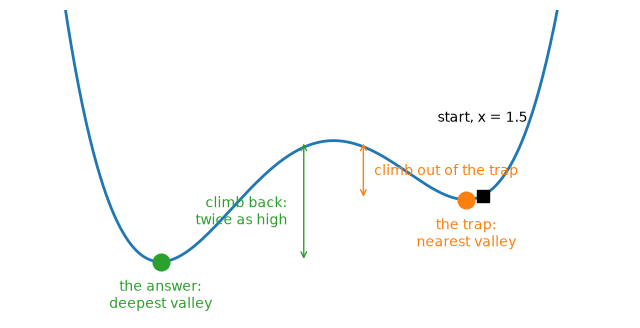

```python
sketch()
```

### The loop with a schedule

```python
def metropolis(x, kT_steps):
    xs = np.zeros(len(kT_steps))
    for i in range(len(kT_steps)):
        kT = kT_steps[i]                                   # the schedule: one kT per step
        dx = np.random.uniform(-0.5, 0.5)                  # proposal: a step of any size up to 0.5
        dE = energy(x + dx) - energy(x)
        if dE <= 0:                                        # down: always
            x = x + dx
        elif kT > 0 and np.random.rand() < np.exp(-dE / kT):   # up: with p (never when kT = 0)
            x = x + dx
        xs[i] = x
    return xs
```

### Three runs from $x = 1.5$

```python
nsteps = 10000
np.random.seed(210)
greedy = metropolis(1.5, np.zeros(nsteps))                  # kT = 0 from the start
fixed = metropolis(1.5, np.ones(nsteps))                    # kT = 1 the whole time
schedule = np.geomspace(3, 0.01, nsteps)                    # slow cooling: 3 -> 0.01
cooled = metropolis(1.5, schedule)
print(f"final x: greedy {greedy[-1]:.2f}   fixed kT {fixed[-1]:.2f}   cooled {cooled[-1]:.2f}")

fig, ax = plt.subplots(1, 2, figsize=(11, 3.4))
ax[0].plot(greedy, label='greedy, kT = 0'); ax[0].plot(fixed, label='fixed kT = 1'); ax[0].plot(cooled, label='cooled 3 -> 0.01')
ax[0].set_xlabel('step'); ax[0].set_ylabel('x'); ax[0].legend()
ax[1].plot(schedule); ax[1].set_yscale('log'); ax[1].set_xlabel('step'); ax[1].set_ylabel('kT of the cooled run')
plt.tight_layout(); plt.show()
```

### What the three runs tell us

| run | $kT$ | ends at | what it is |
| --- | --- | --- | --- |
| greedy | 0 from the start | 1.35, the shallow valley | an **optimiser** that only goes down: stuck in the nearest valley |
| fixed | 1 the whole time | somewhere in a valley, still moving | a **sampler**: visits both valleys in Boltzmann proportion, never settles |
| cooled | 3 → 0.01, slowly | −1.47, the deepest valley | **simulated annealing**: samples while hot, settles while cold |

- The same loop, three schedules. Only the cooled run gives the answer to "where is the minimum?"
- Cool too fast and you get the greedy result: a **quench**

**Poll Q5:** cool too fast?

The cooled run again, but $kT$ falls from 3 to 0.01 within the **first 20 steps** and then stays at 0.01 for the rest (a quench). Starting from $x = 1.5$, where does the walker end most of the time?

A) at −1.47: the schedule still ends cold, so it finds the deepest valley  
B) at 1.35: 20 hot steps are not enough to leave the shallow valley  
C) at 0.13, the top of the barrier  
D) anywhere: at $kT = 0.01$ the walker keeps moving

## A real optimisation: the shortest tour through 12 cities

- **State**: the order in which the cities are visited (a permutation). **Energy**: the length of the tour. **Proposal**: swap two cities. **Test**: the same two lines, with a cooling schedule
- Every tour is a loop: the last city connects back to the first. $12$ cities have $11!/2 \approx 2 \times 10^7$ different tours

### The two functions: tour length, and the loop with a swap

```python
def tour_length(cities, tour):
    xy = cities[tour]                                  # the cities in tour order
    d = xy - np.roll(xy, -1, axis=0)                   # each city minus the next (the last minus the first)
    return np.sum(np.sqrt(d[:, 0]**2 + d[:, 1]**2))

def anneal_tour(cities, tour, kT_steps):
    tour = tour.copy()
    L = tour_length(cities, tour)
    lengths = np.zeros(len(kT_steps))
    for i in range(len(kT_steps)):
        kT = kT_steps[i]
        a, b = np.random.randint(len(tour), size=2)    # proposal: swap two cities
        new = tour.copy(); new[a], new[b] = new[b], new[a]
        dE = tour_length(cities, new) - L              # dE = change of the tour length
        if dE <= 0 or (kT > 0 and np.random.rand() < np.exp(-dE / kT)):
            tour, L = new, L + dE
        lengths[i] = L
    return tour, lengths
```

### Greedy against annealed

```python
np.random.seed(210)
cities = np.random.rand(12, 2)
tour0 = np.arange(12)                                  # visit the cities in the order they were drawn
greedy_tour, greedy_L = anneal_tour(cities, tour0, np.zeros(20000))
best_tour, best_L = anneal_tour(cities, tour0, np.geomspace(0.5, 0.001, 20000))
print(f"start {tour_length(cities, tour0):.3f}   greedy {greedy_L[-1]:.3f}   annealed {best_L[-1]:.3f}")

fig, ax = plt.subplots(1, 3, figsize=(12, 3.4))
for a, tour, title in [(ax[0], tour0, 'start'), (ax[1], greedy_tour, 'greedy, kT = 0'), (ax[2], best_tour, 'annealed')]:
    loop = np.append(tour, tour[0])
    a.plot(cities[loop, 0], cities[loop, 1], 'o-'); a.set_title(f'{title}: {tour_length(cities, tour):.3f}'); a.set_xticks([]); a.set_yticks([])
plt.tight_layout(); plt.show()
plt.plot(greedy_L, label='greedy'); plt.plot(best_L, label='annealed, kT 0.5 -> 0.001')
plt.xlabel('step'); plt.ylabel('tour length'); plt.legend(); plt.show()
```

## Going further: the Ising model

- A 20 × 20 grid of spins, each $+1$ or $-1$. The energy is lowest when neighbours agree: $E = -\sum_{\text{neighbours}} s_i s_j$
- Proposal: flip one spin. $dE$ needs only its four neighbours. Then the same test
- Cold: the spins line up (a magnet). Hot: noise. The switch is sharp, at $kT \approx 2.27$. A Project B topic, if you like it

### The Ising cell

```python
def ising(kT, L=20, nsteps=40000):
    s = np.random.choice([-1, 1], size=(L, L))        # a grid of spins, +1 or -1
    for step in range(nsteps):
        i, j = np.random.randint(L, size=2)            # pick one spin
        neighbours = s[(i + 1) % L, j] + s[(i - 1) % L, j] + s[i, (j + 1) % L] + s[i, (j - 1) % L]
        dE = 2 * s[i, j] * neighbours                  # the cost of flipping it (J = 1)
        p = np.exp(-dE / kT)
        if np.random.rand() < p:                       # the same test as always
            s[i, j] = -s[i, j]
    return s

np.random.seed(210)
fig, ax = plt.subplots(1, 2, figsize=(8, 4))
for a, kT in [(ax[0], 1.5), (ax[1], 4.0)]:
    s = ising(kT)
    a.imshow(s, cmap='gray'); a.set_title(f'kT = {kT}: magnetisation {np.sum(s)} of 400'); a.axis('off')
plt.show()
```

## Reading and explaining code (Topic 15)

This skill is on Test 5, and it is what your defence rehearses: someone else's code, or your own from two weeks ago

### The four moves of code reading

1. **Skim the shape**: functions? loops? what comes in, what goes out?
2. **Trace one pass**: pick small concrete values, walk each line
3. **Predict before running**: commit to a prediction, then check
4. **Interrogate intent**: why is this line here? what breaks without it?

**Poll Q6:** warm-up, one sentence

Read it without running it. Which sentence says what `f` returns?

```python
def f(a):
    out = []
    for i, v in enumerate(a):
        if i % 2 == 0:
            out.append(v * 2)
    return out
```

A) a list with every value of `a` doubled  
B) a list with the values at positions 0, 2, 4, … doubled  
C) a list with the even values doubled  
D) a list with the values at positions 1, 3, 5, … doubled

**Poll Q7:** today's loop, by hand

The "random" numbers are given as lists. What does this print?

```python
import numpy as np

dxs = [1, 1, -1]              # the three proposals
rands = [0.2, 0.9, 0.5]       # the three "random" numbers
kT = 1.0
x = 0
positions = []
for i in range(3):
    dE = (x + dxs[i])**2 - x**2
    p = np.exp(-dE / kT)
    if rands[i] < p:
        x = x + dxs[i]
    positions.append(x)
print(positions)
```

A) `[1, 2, 1]`  
B) `[1, 0]`  
C) `[1, 1, 0]`  
D) `[1, 1, 1]`

### The four moves on that loop

1. **Skim**: three lists in (`dxs`, `rands`, and the one that grows, `positions`), one loop, one `if`; the print is the output
2. **Trace**: step 1: $dE = 1$, $p = 0.37$, accepted · step 2: $dE = 3$, $p = 0.05$, rejected · step 3: $dE = -1$, $p = 2.7$, accepted
3. **Predict**: `[1, 1, 0]`, then run it
4. **Intent**: why is `positions.append(x)` outside the `if`? (the rejected step is recorded too) · what breaks if `p = np.exp(dE / kT)`? (climbs become likely, descents rare: the kernel leaves the wok) · what does `kT = 1.0` do, and what if it were 0.1?

### Why this matters for your projects

- On Test 5: two reading questions in exactly this style (predict the output, pick the one-sentence summary); plus **write today's Metropolis loop as a function** that returns the recorded positions, and fix one bug in it
- At your defence: "walk me through this cell". The four moves **are** the answer
- Code you did not write yourself (a classmate, a book, a tool): reading it critically is how you catch the plausible-but-wrong. The orbit force `-x / r**2` on Day 12 looked right and passed the unit-circle test

## Looking back: the goal from Day 1

*Translate physical laws into computer code that can be used to perform investigations, solve problems and answer questions*

| Day 1 said you would | where you did it |
| --- | --- |
| manage files and programs | Jupyter from Day 1 · paths, missing files, one file per run (Day 17) |
| edit and execute programs | every worksheet · **Restart Kernel and Run All** before every export |
| read and write data files | `savetxt`, `genfromtxt`, `npz`, FITS (Day 17) · Homework 18 |
| manipulate data and calculate | arrays and masks (Days 05–06) · Monte-Carlo (Days 09, 18) · fitting (Day 10) |
| visualize, communicate, interpret | Matplotlib (Day 07) · Project A notebooks and defences |

Physical laws in code this term: Newton and Kirchhoff (`solve_ivp`, Days 11–12, Project A) · Boltzmann (today)

### What to keep when the syntax fades

1. **Predict, then run.** Every poll this term was this
2. **Check against something you know, and show it as a number.** Energy in Project A, the Boltzmann fractions today: rubric row 2
3. **Create reproducible code (restart kernel and run all).** If a result does not survive a restart, it is not a result yet
4. **Produce, then analyse.** Save the slow part to a file; make the plots from the file
5. **Read code before you trust it**: your own, a classmate's, a book's, a tool's

### Where this goes next

- **Tools you will meet**: `git` (a history of every version of your code) · more of SciPy (`integrate`, `optimize`, `stats`) · `pandas` for tables · code in `.py` files with tests
- **Courses**: PHYS 310 (Machine Learning for Physics and Astronomy Data Analysis) builds on the same tools: NumPy, data files, plots, checks · PHYS 410 (Computational Physics) goes deeper into the methods: linear systems, ODEs and PDEs, Monte-Carlo
- **Labs and research** (summer research, co-op, a thesis) run the same steps: read the data, simulate or fit, check, show the plot, explain it to someone

### Your feedback, and thank you

- **Course survey (SEI)**: open from today until Thu Dec 10. Tell us what to keep and what to change: the readings and polls, the worksheets, the tests at the testing centre, the projects and defences. Every comment is read, and next year's course changes because of them
- **Thank you**: for the questions in class, on Piazza and at the defences, and to our TAs, who were in the room every day
- Not goodbye yet: three studios, Test 5 and the Project B defences are still ahead

# The rest of today, and before you leave

- **Homework 18** (the n² gas: scan $kT$, write the table to a file, read it back and compare with theory; annealing on today's landscape) due **Wed Nov 25, 9:00 am**. **Restart Kernel and Run All Cells before you export**
- **No reading for Wednesday**: Wednesday is a studio day
- **Course survey (SEI)**: open until Thu Dec 10
- **Project B**: draft checkpoint Mon Nov 30 (a TA goes through your notebook with the rubric; not marked) · defences Mon Dec 7
- **Test 5** Mon Nov 30 – Fri Dec 4 (file I/O, reading code, Monte-Carlo 2; not cumulative) · Practice sets open on PrairieLearn after class today; the file I/O set now has 6 questions · Practice Test 5 opens Tue Nov 24